# STERGM tutorial on social networks

## Introduction

The present tutorial replicates the analysis performed by [Marina et al. (2023)](https://doi.org/10.3168/jds.2023-23483). We will analyse information from a Swedish commercial dairy farm. The farm has installed an ultra-wideband based Real-Time Location System (RTLS) that provides the location of all the cows on the farm. Lactating cows were equipped with a tag attached to their collars. Using the position information of the cows, we can estimate daily spatial interaction networks and study how cow characteristics affect the network structure.

1. Farm information
2. Animal information
3. Social contact information
4. Build the networks
5. Represent social networks
6. Analysing social networks
7. Representing stERGM estimates

#### Required packages

```r
library(statnet)
library(texreg)
library(reshape2)
library(ndtv)
library(forcats)
library(ggplot2)
```

## Farm information

Position data was collected from a Swedish commercial dairy farm. This farm housed around 210 lactating dairy cows (Holstein, Red Dairy Cattle, and Crossbred) in a non-insulated free-stall barn (Figure 1). The farm is divided into two milking groups: early (G1) and late (G2) lactation groups. We defined two functional areas within the barn: the resting area consisting of the cubicles and the inner alleys and the feeding area composed of the alleys beside the feeding tables and outer alleys. Further information about the farm can be found in [Hansson et al. (2023)](https://doi.org/10.3168/JDS.2022-21915).

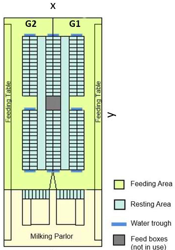

**Figure 1**. Schematic map of the free-stall barn under study (74 × 33m), where y and x represent the direction of the y- and x-axis. The farm is divided into two milking groups: early (G1) and late (G2) lactation groups. The cubicles are in the central parts of the barn and the feeding tables along both sides. The beige area is outside the boundaries of the cows in the milking group, except for transport between the pen area and the milking parlor.

## Animal information

First, we read the information about the cows in the late lactation group at this Swedish dairy farm. Cow information contains:

- `Phenotypes_LateLactationGroup.csv`: Contains cows’ individual information fitted in the separable temporal Exponential Random Graph Model (stERGM).
  - *ID*: Identification number for the social network matrices.
  - *Parity*: Number of current lactation.
  - *Lactation_stage*: Stage of lactation [Early (7- 49 Days in Milk), Mid (50 -179 DIM) or Late (≥180 DIM)].
  - *Pregnancy_status*: Stage of pregnancy (0: Open, 1: Pregnant).
  - *Breed*: Breed of each cow (HOL: Holstein, RDC: Red Dairy Cattle or CROSS: Crossbreed).
  - *Claw_health*: Status of claw (0: Healthy, 1: Minor or mayor lesions).
  - *Time_in_area*: Proportion of time each animal spent per day in the feeding area by dividing it by the total time reported by the RTLS.
  - *Lactation_group*: Late lactation group was mainly composed of mid to late-lactation.

```r
Pheno=read.table("../data/raw/Phenotypes_LateLactationGroup.csv", header = TRUE, sep = ",")
```

- `AGEcontemporary_LateLactationGroup.csv`: Contains the kindergarten effect matrix (`AGEcont`). The kindergarten effect, or contemporary age, represents animals born within seven days in the same farm being equal to 1, if two cows were contemporary, and 0 otherwise.

```r
AGEcont=as.matrix(read.table("../data/raw/Relationshipdata/AGEcontemporary_LateLactationGroup.csv", header = FALSE, sep = ","))
colnames(AGEcont)=rownames(AGEcont)=c(1:ncol(AGEcont))
```

- `DIMcontemporary_LateLactationGroup.csv`: Contains the lactational effect matrix (`DIMcont`). The lactational effect, or contemporary DIM, represents cows that calved within seven days being equal to 1, if two cows were contemporary, and 0 otherwise.

```r
DIMcont=as.matrix(read.table("../data/raw/Relationshipdata/DIMcontemporary_LateLactationGroup.csv", header = FALSE, sep = ","))
colnames(DIMcont)=rownames(DIMcont)=c(1:ncol(DIMcont))
```

- `PEDcontemporary_LateLactationGroup.csv`: Contains the additive relationship matrix (`PEDmat`). The relationship coefficients were calculated from the pedigree.

```r
PEDmat=as.matrix(read.table("../data/raw/Relationshipdata/PEDrelation_LateLactationGroup.csv", header = FALSE, sep = ","))
colnames(PEDmat)=rownames(PEDmat)=c(1:ncol(PEDmat))
```

*The kindergarten and lactational effect contained a total of 31 animals and 135 contemporary relationships, respectively. The additive relationship matrix contained eight pair of animals with with a relationship coefficient higher than 0.5, indicating a parental-offspring filial relationship.*

## Social contact information

The position data automatically collected with the ultra-wideband RTLS with a one-second fixed rate were used to estimate the distance among the 76 lactating cows held in the late lactation group. We assumed that a pair of cows interacted socially when they spent more than 10 minutes per day at a minimum distance of 2.5 m. Interaction matrices, known as adjacency matrices in graph theory terminology, were computed independently for each functional area (“FeedingArea”,“RestingArea”) and each day (i.e., 24 h) of the 14 days considered in this study. Data from the adjacency matrices is coded in a binary format, where 1’s denote the occurrence of a contact, and 0’s indicate that no contact longer than 10 minutes was registered during the day. Following, we read the social contact information for the cows held the late lactation group within each functional area and per day.

```r
functionalarea=c("FeedingArea","RestingArea") # Functional areas
ADJmat=list()
for (i in functionalarea){
  for (day in c(1:14)){
      ADJmat[[i]][[day]]=as.matrix(read.table(
        paste0("../data/raw/Interactiondata/Adjacencymatrix_",i,"_LateLactationGroup_day",day,".csv"), header = FALSE, sep = ","))
    rownames(ADJmat[[i]][[day]])=c(1:nrow(ADJmat[[i]][[day]]))
    colnames(ADJmat[[i]][[day]])=c(1:ncol(ADJmat[[i]][[day]]))
  }
}
```

## Build the networks

We will transform the adjacency matrices information into undirected graphs using the `network` package.

```r
ADJGraph=list()
for (i in functionalarea){
  for (day in c(1:14)){
    ADJGraph[[i]][[day]]=network::network(as.matrix(ADJmat[[i]][[day]]),directed=FALSE)
  }
}
```

Save list of networks as dynamic network objects for each functional area, independently.

```r
DynamicGraph=list()
for (i in functionalarea){
  DynamicGraph[[i]] = networkDynamic(network.list = ADJGraph[[i]], start = 1, end = 14)
}
```

## Represent social networks

```r
node_colors=as.character(Pheno$Parity)
node_colors=ifelse(node_colors=="1","purple",ifelse(node_colors=="2","blue","red"))
```

Size of the nodes will be based on the number of social contact established on that day, known as degree in graph theory terminology. Degree will be estimated using the `sna`package.

```r
FA_degree=sna::degree(ADJGraph[["FeedingArea"]][[1]], gmode="graph")
RA_degree=sna::degree(ADJGraph[["RestingArea"]][[1]], gmode="graph")
```

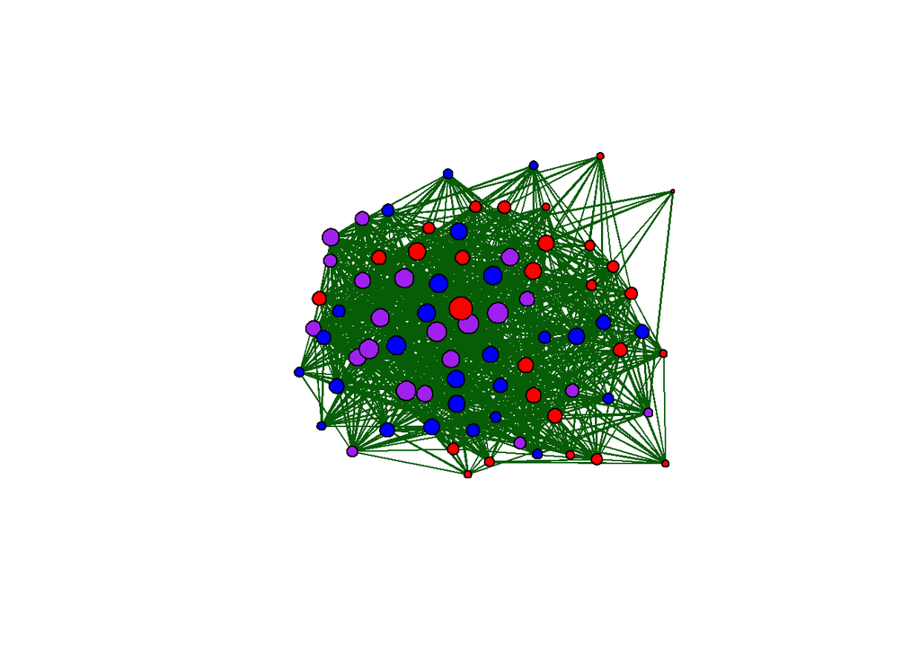

```r
plot.network(ADJGraph[["FeedingArea"]][[1]],
             vertex.col = node_colors,
             vertex.cex = ((FA_degree)/max(FA_degree))*3,
             edge.col = "#065d06")
```

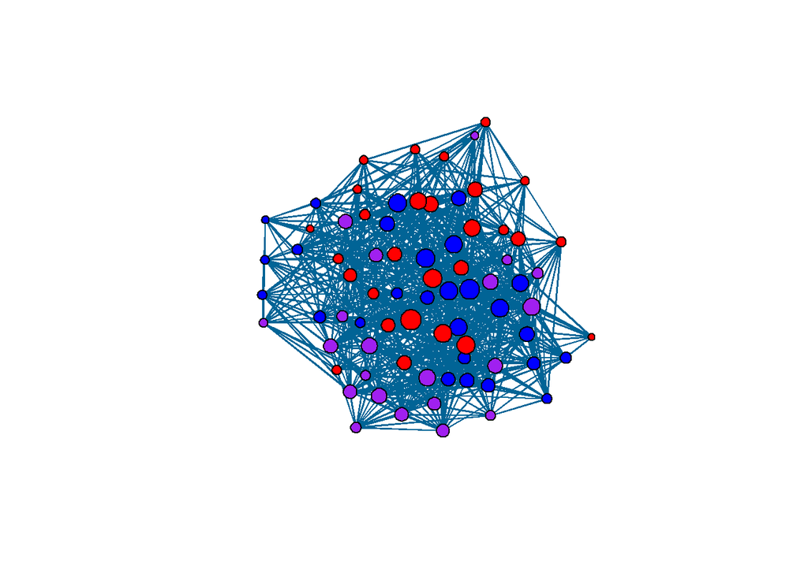

```r
plot.network(ADJGraph[["RestingArea"]][[1]],
             vertex.col = node_colors,
             vertex.cex = ((RA_degree)/max(RA_degree))*3,
             edge.col = "#016496")
```

In addition, dynamic networks can be represented as animations. In this tutorial, each transition represents the changes occurred between daily networks.

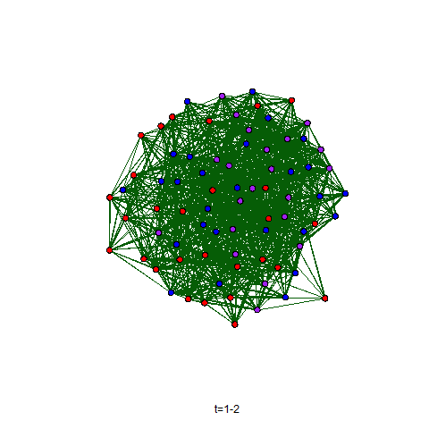

```r
saveGIF({render.animation(DynamicGraph[["FeedingArea"]],
                            displaylabels=F,
                            vertex.col=node_colors,
                            edge.col="#065d06",
                            render.cache='none')},
        movie.name=paste0("Figure2_FA.gif"))
```

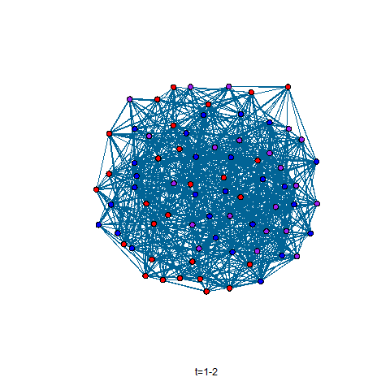

```r
saveGIF({render.animation(DynamicGraph[["RestingArea"]],
                          displaylabels=F,
                          vertex.col=node_colors,
                          edge.col="#016496",
                          render.cache='none')},
        movie.name=paste0("Figure2_RA.gif"))
```

## Analyzing social networks

With the aim of assessing the role of the cows’ characteristics, included in `Pheno` dataframe, on the likelihood of establishing social interactions, we will implement the information from the social networks into the `statnet` package. We will apply the separable temporal exponential-family random graph model (stERGM), described by [Krivitsky and Handcock (2010)](https://doi.org/10.1111/rssb.12014), to explore the evolution of social networks over the 14 days considered in this tutorial. To this aim, we will include the cows’ information into the dynamic networks.

```r
for (i in functionalarea){
  DynamicGraph[[i]] %v% "Parity"          = as.character(Pheno$Parity)
  DynamicGraph[[i]] %v% "Pregnancy_status"= as.character(Pheno$Pregnancy_status)
  DynamicGraph[[i]] %v% "Lactation_stage" = as.character(Pheno$Lactation_stage)
  DynamicGraph[[i]] %v% "Breed"           = as.character(Pheno$Breed)
  DynamicGraph[[i]] %v% "Claw_health"     = as.character(Pheno$Claw_health)
  DynamicGraph[[i]] %v% "Time_in_area"    = as.numeric(  Pheno$Time_in_area)
}
```

Likewise, we will implement in the model the kindergarten and lactational effect, and the relationship coefficient to assess the effect of having shared early life experiences, or in the last drying period together, or sharing a filial relationship into the likelihood of establishing social contacts.

```r
AGEGraph=network::network(AGEcont, directed=FALSE)
DIMGraph=network::network(DIMcont, directed=FALSE)
PEDGraph=network::network(matrix(1,ncol(PEDmat),ncol(PEDmat)), directed=FALSE)

A=reshape2::melt(PEDmat)
A=A[A$Var1<A$Var2,]
A=A[order(A$Var1,A$Var2),]
network::set.edge.attribute(PEDGraph, "PEDGraph",A[,3])
```

The fitted stERGM consists of two fitted logistic regressions, one for the formation part of the model, and one for the persistence part of the model. Each model includes an intercept, five node factor effects, five node match effects, one node covariable and three edge covariables. Therefore, for each of the fitted variables we will obtain two estimates, one for the formation effect and one for the persistence effect.

```r
stERGMestimates=list()
for (i in functionalarea){
  stERGMestimates[[i]] = stergm(DynamicGraph[[i]],
                formation   = ~ edges  +
                              nodefactor("Parity")           + nodematch("Parity")            +
                              nodefactor("Pregnancy_status") + nodematch("Pregnancy_status")  +
                              nodefactor("Lactation_stage")  + nodematch("Lactation_stage")   +
                              nodefactor("Breed")            + nodematch("Breed")             +
                              nodefactor("Claw_health")      + nodematch("Claw_health")       +
                              nodecov("Time_in_area")        +
                              edgecov(AGEGraph, attrname=NULL) +
                              edgecov(DIMGraph, attrname=NULL) +
                              edgecov(PEDGraph, "PEDGraph"),
                dissolution = ~ edges  +
                              nodefactor("Parity")           + nodematch("Parity")            +
                              nodefactor("Pregnancy_status") + nodematch("Pregnancy_status")  +
                              nodefactor("Lactation_stage")  + nodematch("Lactation_stage")   +
                              nodefactor("Breed")            + nodematch("Breed")             +
                              nodefactor("Claw_health")      + nodematch("Claw_health")       +
                              nodecov("Time_in_area")        +
                              edgecov(AGEGraph, attrname=NULL) +
                              edgecov(DIMGraph, attrname=NULL) +
                              edgecov(PEDGraph, "PEDGraph"),
                estimate = "CMLE",
                times=1:14)
}
```

## Representing stERGM estimates

Below are the estimates of formation and persistence obtained by implementing stERGM for the feeding area and for the resting area. Presenting the estimates together helps us to get an idea of the importance of each cow’s characteristic for the establishment of social contacts.

```r
texreg::screenreg(stERGMestimates, custom.model.names = functionalarea)
```

```
##
## ====================================================================
##                                         FeedingArea    RestingArea
## --------------------------------------------------------------------
## Form~edges                                  -2.82 ***      -0.51 **
##                                             (0.17)         (0.16)
## Form~nodefactor.Parity.2                    -0.05           0.02
##                                             (0.03)         (0.03)
## Form~nodefactor.Parity.3+                   -0.03           0.01
##                                             (0.03)         (0.03)
## Form~nodematch.Parity                        0.18 ***       0.13 ***
##                                             (0.03)         (0.03)
## Form~nodefactor.Pregnancy_status.1           0.10 **        0.12 **
##                                             (0.04)         (0.04)
## Form~nodematch.Pregnancy_status             -0.02          -0.04
##                                             (0.04)         (0.04)
## Form~nodefactor.Lactation_stage.Mid          0.09 *         0.01
##                                             (0.04)         (0.04)
## Form~nodematch.Lactation_stage               0.01           0.05
##                                             (0.05)         (0.04)
## Form~nodefactor.Breed.HOL                   -0.06 *        -0.07 *
##                                             (0.03)         (0.03)
## Form~nodefactor.Breed.RDC                   -0.25 ***      -0.04
##                                             (0.03)         (0.03)
## Form~nodematch.Breed                        -0.03          -0.03
##                                             (0.03)         (0.03)
## Form~nodefactor.Claw_health.1               -0.04          -0.10 ***
##                                             (0.03)         (0.03)
## Form~nodematch.Claw_health                   0.02           0.06 *
##                                             (0.03)         (0.03)
## Form~nodecov.Time_in_area                    2.33 ***      -0.82 ***
##                                             (0.16)         (0.15)
## Form~edgecov.AGEGraph                        0.80 ***       0.65 ***
##                                             (0.16)         (0.14)
## Form~edgecov.DIMGraph                        0.07           0.01
##                                             (0.07)         (0.07)
## Form~edgecov.PEDGraph                        0.97 **        1.20 ***
##                                             (0.37)         (0.35)
## Persist~edges                               -2.90 ***       0.01
##                                             (0.22)         (0.22)
```

[output cut: 25 more lines]

```
##                                             (0.21)         (0.21)
## Persist~edgecov.AGEGraph                     0.56 ***       0.37 *
##                                             (0.14)         (0.15)
## Persist~edgecov.DIMGraph                     0.13           0.14
##                                             (0.08)         (0.09)
## Persist~edgecov.PEDGraph                     0.92 *        -0.26
##                                             (0.45)         (0.47)
## --------------------------------------------------------------------
## independence                                 1              1
## iterations                                   4              4
## Log Likelihood                          -22522.00      -22641.28
## AIC                                      45111.99       45350.57
## BIC                                      45401.67       45640.25
## ====================================================================
## *** p < 0.001; ** p < 0.01; * p < 0.05
```

**Table S2**. Formation and persistence conditional log-odds ratios estimated through the stERGM implementation. The standard error is shown between brackets (* p < 0.05; ** p < 0.01; *** p < 0.001).

However, a figure makes it easier to read and compare the stERGM estimates. Therefore, the following code will focus on presenting these results in the same figure. First, we will extract the estimates of formation and persistence into tables.

```r
Feed.df=as.data.frame(summary(stERGMestimates[[1]])$coef)
Rest.df=as.data.frame(summary(stERGMestimates[[2]])$coef)

colnames(Feed.df)=c("Estimates","SE","MCMC %","z.value","p.value")
colnames(Rest.df)=c("Estimates","SE","MCMC %","z.value","p.value")
```

Following, we will standardize the names of the estimates following [Marina et al. (2023)](https://doi.org/10.3168/jds.2023-23483).

```r
rowN=c("edges","factor(Parity: 2)","factor(Parity: 3+)","match(Parity)",
       "factor(Pregnancy status: Pregnant)","match(Pregnancy status)",
       "factor(Lactation stage: Middle)","match(Lactation stage)",
       "factor(Breed: Holstein)","factor(Breed: Red dairy cattle)","match(Breed)",
       "factor(Claw health: Remark)","match(Claw health)",
       "covariable(Time in area)", "covariable(Agecont)","covariable(DIMcont)","covariable(REL)")
Feed.df$FixedEffects=rep(rowN,2)
Rest.df$FixedEffects=rep(rowN,2)
```

Include model information Include model information in the dataframes.

```r
Feed.df$Model=c(rep("Formation",17),rep("Persistence",17))
Rest.df$Model=c(rep("Formation",17),rep("Persistence",17))
```

Filtering the estimates for `edges` and `Time in area`. Time in area corrects the probability of an existing edge by the time spent in the functional area. Therefore, the inclusion of this covariate is imperative, as the more time the animals spend in each functional area, the greater the likelihood of random interactions.

```r
Feed.df=Feed.df[!grepl("edges",        Feed.df$FixedEffects), ]
Feed.df=Feed.df[!grepl("Time in area", Feed.df$FixedEffects), ]
Rest.df=Rest.df[!grepl("edges",        Rest.df$FixedEffects), ]
Rest.df=Rest.df[!grepl("Time in area", Rest.df$FixedEffects), ]
```

Order the fixed effects included in the model following [Marina et al. (2023)](https://doi.org/10.3168/jds.2023-23483).

```r
FFlevels=c(Feed.df$FixedEffects[15:1])
Feed.df$FixedEffects=factor(Feed.df$FixedEffects, levels = FFlevels)
Feed.df$Model=       factor(Feed.df$Model, levels=c("Formation","Persistence"))
Feed.df$Model=       forcats::fct_relevel(Feed.df$Model, c("Formation","Persistence"))
Rest.df$FixedEffects=factor(Rest.df$FixedEffects, levels = FFlevels)
Feed.df$Model=       factor(Rest.df$Model, levels=c("Formation","Persistence"))
Rest.df$Model=       forcats::fct_relevel(Rest.df$Model, c("Formation","Persistence"))
```

Set colors for formation and persistence estimates in the feeding (green) and resting (blue) areas.

```r
Colors=list()
Colors[[1]]=c("#0A960A","#065d06")
Colors[[2]]=c("#0080c1","#016496")
```

Determine the percentage confidence interval of the estimates. The figure will represent the 95% confidence interval.

```r
ConfInt=1.96
```

Now we are ready to depict the formation and persistence log-odds ratios estimated through the separable temporal exponential random graph models (stERGM):

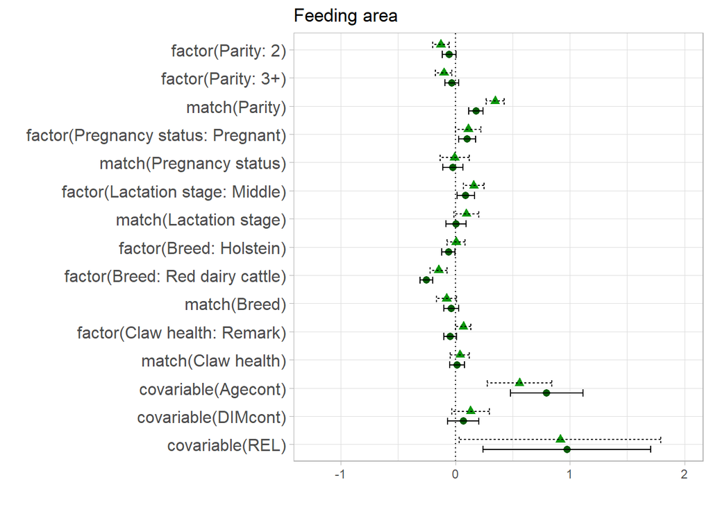

```r
ggplot(Feed.df,aes(x = FixedEffects, y = Estimates, col=as.factor(Model))) +
  geom_hline(yintercept = 0,linetype = "dotted") +
  geom_point(aes(shape = Model),size=2.2, position = position_dodge(width = 0.7)) +
  geom_errorbar(aes(ymin = Estimates - (SE * ConfInt), ymax = Estimates + (SE * ConfInt), linetype = ifelse(Feed.df$Model=="Formation", "dashed", "solid")),  width = 0.5, colour = "black", alpha = 1.0, size = 0.5, position = position_dodge(width = 0.7), show.legend = FALSE) +
  scale_color_manual(values = c(Colors[[1]][2], Colors[[1]][1])) +
  theme_light() + theme(legend.position = "none", axis.text.y = element_text(size = 12))+
  coord_flip() + scale_x_discrete(labels = FFlevels) +
  ylim(-1.25,2) + xlab("") + ylab("") + ggtitle("Feeding area")
```

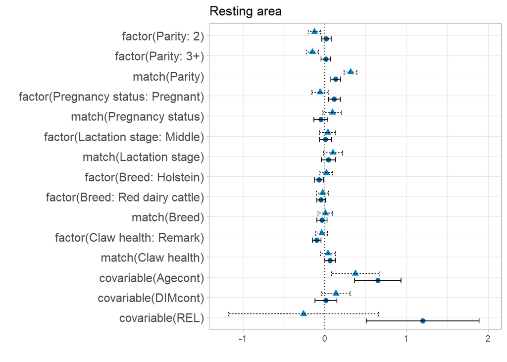

```r
ggplot(Rest.df,aes(x = FixedEffects, y = Estimates, col=Model)) +
  geom_hline(yintercept = 0,linetype = "dotted") +
  geom_point(aes(shape = Model),size=2.2, position = position_dodge(width = 0.7)) +
  geom_errorbar(aes(ymin = Estimates - (SE * ConfInt), ymax = Estimates + (SE * ConfInt), linetype = ifelse(Rest.df$Model=="Formation", "dashed", "solid")), width = 0.5, colour = "black", alpha = 1.0, size = 0.5, position = position_dodge(width = 0.7), show.legend = FALSE) +
  scale_color_manual(values = c(Colors[[2]][2], Colors[[2]][1])) +
  theme_light() + theme(legend.position = "none", axis.text.y = element_text(size = 12))+
  coord_flip() + scale_x_discrete(labels = FFlevels) +
  ylim(-1.25,2) + xlab("") + ylab("") + ggtitle("Resting area")
```

### Citation and contact information

I hope this has been useful. If you use information from external sources, make sure to cite them properly:

> Marina, H., Ren, K., Hansson, I., Fikse, F., Nielsen, P.P., Rönnegård, L., 2023. New insight into social relationships in dairy cows, and how time of birth, parity and relatedness affect spatial interactions later in life. J. Dairy Sci. https://doi.org/10.3168/JDS.2023-23483

For any questions or further information, please contact the authors:

- [Hector Marina](https://www.slu.se/en/ew-cv/hector-marina/) (hector.marina@slu.se)
- [Keni Ren](https://www.slu.se/en/ew-cv/keni-ren/) (keni.ren@slu.se)
- [Ida Hansson](https://www.slu.se/en/ew-cv/hector-marina/) (ida.hansson@slu.se)
- [Freddy Fikse](https://www.vxa.se/toppmeny/kontakter/uppsala/freddy-fikse/) (freddy.fikse@vxa.se)
- [Per Peetz Nielsen](https://www.ri.se/sv/person/per-peetz-nielsen) (per.peetz.nielsen@ri.se)
- [Lars Rönnegård](https://www.slu.se/cv/lars-ronnegard/) (lars.ronnegard@slu.se)